# Data Visualization via ggplot2

Tim Dennis

2018-10-15

## Introduction

- By visualizing our data, we will be able to gain valuable insights from our data that we couldn’t see from just looking at the raw data in spreadsheet form.
- We will use the `ggplot2` package because it provides an easy way to customize your plots and is rooted in the data visualization theory known as *The Grammar of Graphics* [@wilkinson2005].
- **Graphics/plots/charts** provide a nice way for us to get a sense for how quantitative variables compare in terms of their **center** (where the values tend to be located) and their spread (how they vary around the center).
- The most important thing to know about graphics is that they should be created to make it obvious for your audience to understand the findings and insight you want to get across.
- This does however require a balancing act:
  - You want to highlight as many meaningful relationships and interesting findings as possible
  - **BUT** you don’t want to include so many as to overwhelm your audience.
- Identify patterns and outliers in our data.

### Needed packages

```r
library(nycflights13)
library(ggplot2)
library(dplyr)
library(ggmap)
library(lubridate)
```

## The Grammar of Graphics

- Start with a theoretical framework for data visualization known as the “The Grammar of Graphics,” which serves as the basis for the `ggplot2` package.
- Just like how we construct sentences in any language by using a linguistic grammar (nouns, verbs, subjects, objects, etc.), the theoretical framework given by Leland Wilkinson [@wilkinson2005] allows us to specify the components of a statistical graphic.

### Components of the Grammar

In short, the grammar tells us that:

> **A statistical graphic is a `mapping` of `data` variables to `aes`thetic attributes of `geom`etric objects.**

Specifically, we can break a graphic into the following three essential components:

1. `data`: the data-set comprised of variables that we map.
2. `geom`: the geometric object in question. This refers to our type of objects we can observe in our plot. For example, points, lines, bars, etc.
3. `aes`: aesthetic attributes of the geometric object that we can perceive on a graphic. For example, x/y position, color, shape, and size. Each assigned aesthetic attribute can be mapped to a variable in our data-set.

### The ggplot2 package

- ggplot2 is an implementation of the g - o - g
- it’s layered - think of photoshop - we define the data, specified components, we then add *layers* to the plot using the `+` sign.
- The most essential layer to add to a plot is the specification of which type of `geom`etric object we want the plot to involve; e.g. points, lines, bars.
- Other layers we can add include the specification of the plot title, axes labels, facets, and visual themes for the plot.
- Let’s now put the theory of the Grammar of Graphics into practice.

## Graphs - Some basic ways of visualizing data

For our purposes, we will be limiting consideration a number different types of graphs.

1. scatterplots
2. linegraphs
3. boxplots
4. histograms
5. barplots
6. maps

We will discuss some variations of these plots, but with this basic repertoire in your toolbox you can visualize a wide array of different data variable types. Note that certain plots are only appropriate for categorical/logical variables and others only for quantitative variables. You’ll want to quiz yourself often as we go along on which plot makes sense a given a particular problem or data-set.

## Linegraphs

We’ll use ridership data from MBTA Performance Dashboard for Boston for generating a line graph of average weekly ridership by each subway line. Let’s load the data first:

```r
rider_rawdata <- read_csv('data/mbta_ridership2016.csv')
#View(rider_rawdata)
```

- Most frequently used when the x-axis represents time and the y-axis represents some other numerical variable; such plots are known as *time series*.
- Time represents a variable that is connected together by each day following the previous day.
- Linegraphs should be avoided when there is not a clear sequential ordering to the explanatory variable, i.e. the x-variable or the *predictor* variable.

Our focus now turns to the `MODE_TYPE` variable in this `ridership` data-set. We will set up a dplyr change to do a few things to prep this data for graphing. We will go into more in-depth how this works next week, but here’s what we are doing:

1. Since we only want to look at rail lines, let’s filter by that in our dataframe.
2. We also will take the opportunity to rename our varaibles so they easier to read on a graph

```r
railrides <- rider_rawdata %>%
  filter(MODE_TYPE =="RAIL") %>%
  rename(Month = SERVICE_MONTH, Mode = MODE_TYPE, Avg_Weekday_Ridership = TOTAL_WEEKDAY_RIDERSHIP_COUNT, Line = ROUTE_OR_LINE)
```

- The above selects only those rows in `rider_rawdata` where the mode type is `"RAIL"`.

### Linegraphs via geom_line

We plot a linegraph of average weekday ridership by month per rail ‘line’:

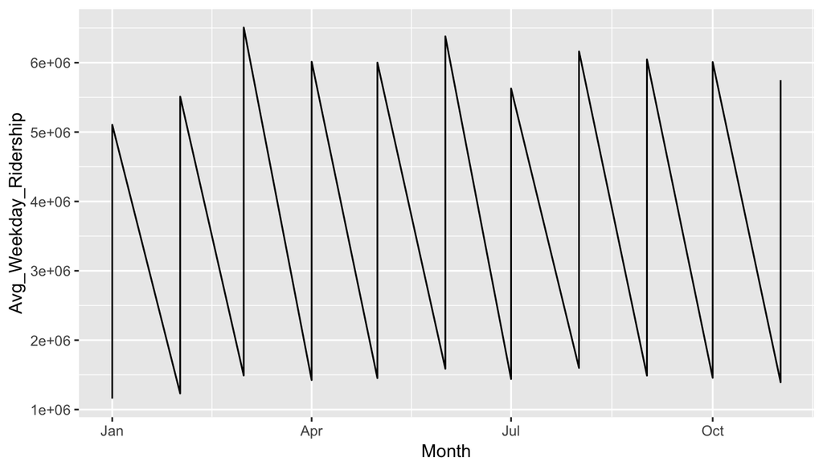

Avg. Weekday MBTA Subway Ridership 2016

```r
ggplot(data = railrides,
       mapping = aes(x = Month, y = Avg_Weekday_Ridership)) +
  geom_line()
```

Was this what you expected?

- We wanted a line per rail line - this is aggregated across lines
- Let’s fix by adding a `group` component and `color` to ggplot

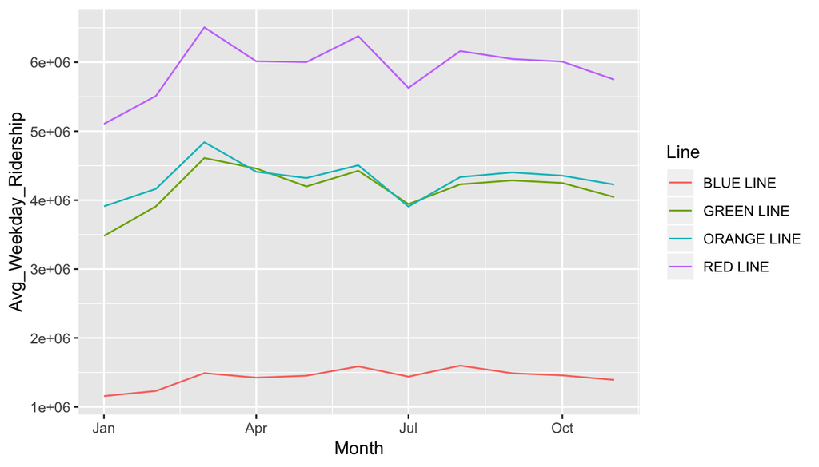

Avg. Weekday MBTA Subway Ridership 2016

```r
ggplot(data = railrides,
       mapping = aes(x = Month, y = Avg_Weekday_Ridership,group=Line, color=Line)) +
  geom_line()
```

- Ok what’s wrong here?
  - yes, the colors are off in the ledgend
  - also let’s fix the Y scale

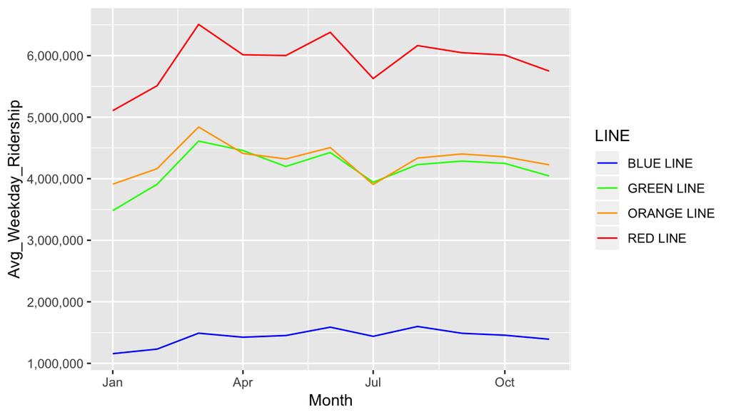

Avg. Weekday MBTA Subway Ridership 2016

```r
ggplot(data = railrides,
       mapping = aes(x = Month, y = Avg_Weekday_Ridership,group=Line, color=Line)) +
  geom_line() +
  scale_y_continuous(labels = scales::comma) +
  scale_color_manual(name="LINE",values=c("BLUE LINE"="blue","GREEN LINE"="green","ORANGE LINE"="orange","RED LINE"="red"))
```

- ggplot is very granular in its settings.

*Learning check*

**(LC3.1)** Why should linegraphs be avoided when there is not a clear ordering of the horizontal axis?

**(LC3.2)** Why are linegraphs frequently used when time is the explanatory variable?

### Summary

Linegraphs, just like scatterplots, display the relationship between two numerical variables. However, the variable on the x-axis (i.e. the explanatory variable) should have a natural ordering, like some notion of time. We can mislead our audience if that isn’t the case.

## Barplots

### Barplots via geom_bar/geom_col

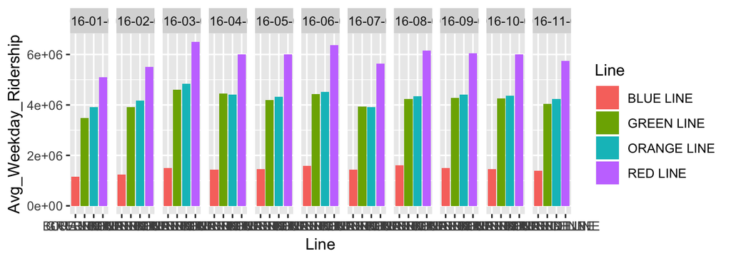

```r
ggplot(data = railrides, mapping = aes(x = Line, y = Avg_Weekday_Ridership, fill=Line)) +
  geom_col() + facet_grid(~Month)
```

*Learning check*

**(LC3.3)** Why are histograms inappropriate for visualizing categorical variables?

**(LC3.4)** What is the difference between histograms and barplots?

### Using barplots to compare two categorical variables

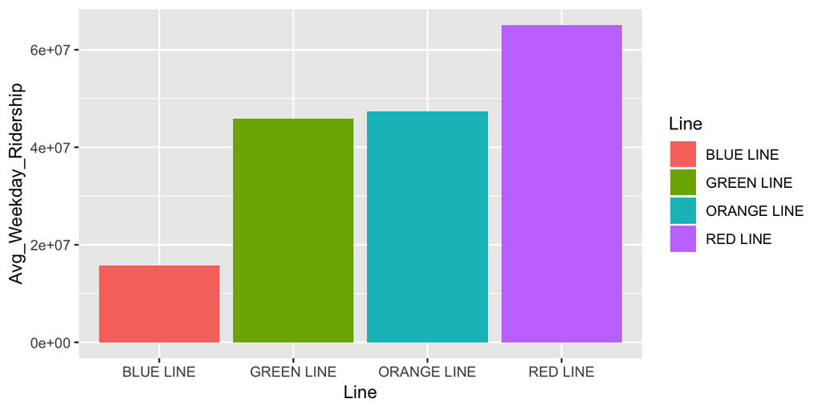

```r
ggplot(data = railrides,
       mapping = aes(x = Line, y=Avg_Weekday_Ridership, fill = Line)) +
  geom_col()  +
 scale_color_manual(name="Line",values=c("BLUE LINE"="blue","GREEN LINE"="green","ORANGE LINE"="orange","RED LINE"="red"))
```

*Learning check*

**(LC3.7)** What kinds of questions are not easily answered by looking at the above figure?

Another variation on the stacked barplot is the *side-by-side barplot* also called a *dodged barplot*.

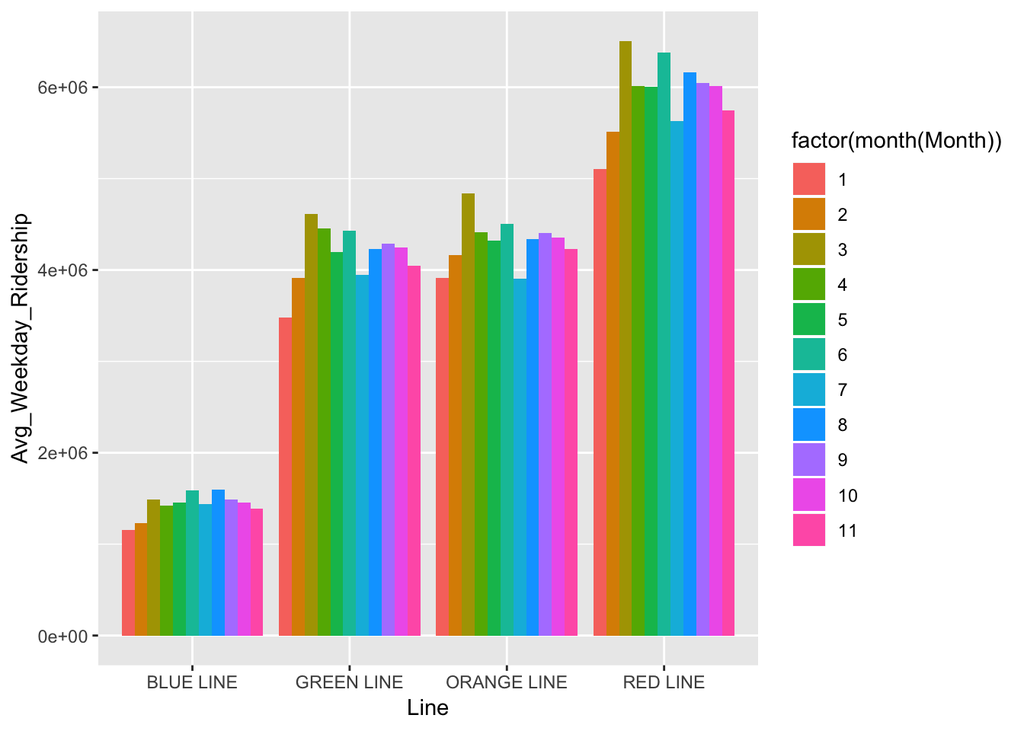

```r
ggplot(data = railrides,
       mapping = aes(x = Line, y =Avg_Weekday_Ridership, fill = factor(month(Month)))) +
  geom_col(position = "dodge")
```

*Learning check*

**(LC3.9)** Why might the side-by-side (AKA dodged) barplot be preferable to a stacked barplot in this case?

**(LC3.10)** What are the disadvantages of using a side-by-side (AKA dodged) barplot, in general?

Lastly, an often preferred type of barplot is the *faceted barplot*. This concept of faceting and small multiples. This gives us a nicer way to compare the distributions across both `Line` and `Avg_Weekday_Ridership` by `Month`. We will also use the `lubridate` package to clean up the month.

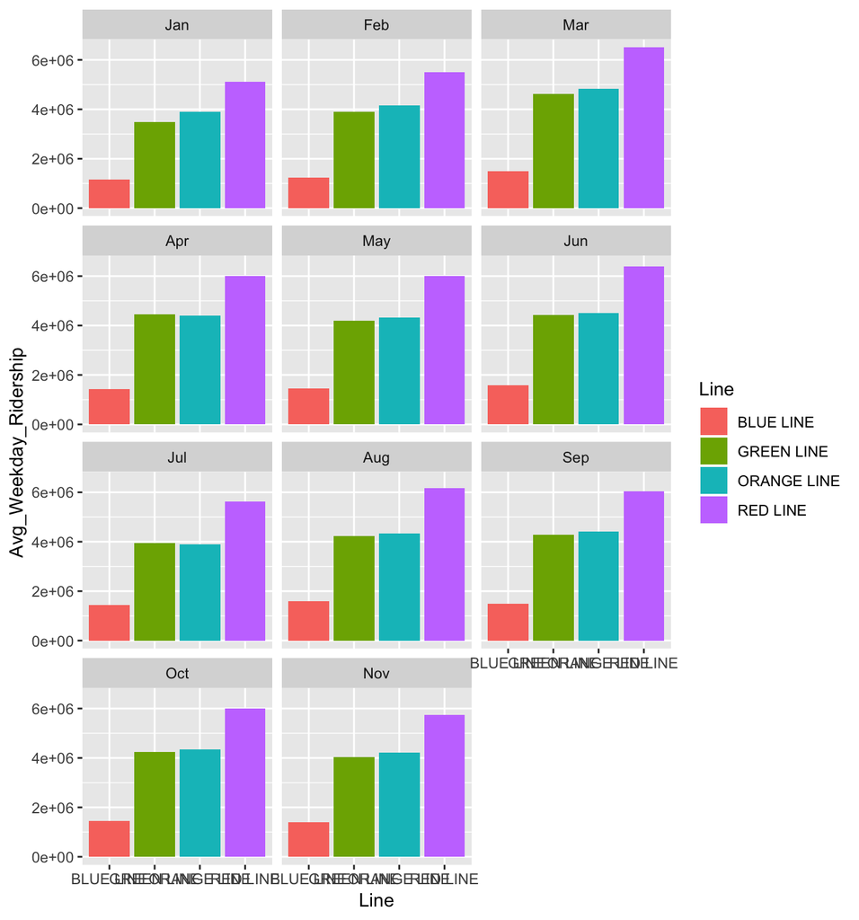

```r
ggplot(data = railrides,
       mapping = aes(x = Line, y = Avg_Weekday_Ridership, fill = Line)) +
  geom_col() +
  facet_wrap(~ month(Month, label=T), nrow = 5)
```

*Learning check*

**(LC3.11)** Why is the faceted barplot preferred to the side-by-side and stacked barplots in this case?

### Summary

Barplots are the preferred way of displaying categorical variables. They are easy-to-understand and make it easy to compare across groups of a categorical variable. When dealing with more than one categorical variable, faceted barplots are frequently preferred over side-by-side or stacked barplots. Stacked barplots are sometimes nice to look at, but it is quite difficult to compare across the levels since the sizes of the bars are all of different sizes. Side-by-side barplots can provide an improvement on this, but the issue about comparing across groups still must be dealt with.

### Resources

An excellent resource as you begin to create plots using the `ggplot2` package is a cheatsheet that RStudio has put together entitled “Data Visualization with ggplot2” available

- by clicking [here](https://www.rstudio.com/wp-content/uploads/2016/11/ggplot2-cheatsheet-2.1.pdf) or
- by clicking the RStudio Menu Bar -> Help -> Cheatsheets -> “Data Visualization with `ggplot2`”

This cheatsheet covers more than what we’ve discussed in this chapter but provides nice visual descriptions of what each function produces.